# R ile Veri Analizinde *Tidyverse* Yaklaşımı

## 6.2 Renk, şekil, ve büyüklük

- Grafiğimize renkleri, şekilleri, ve büyüklükleri kullanarak başka bir değişkenin bilgisini ekleyebiliriz. Renk ve şekiller kategorik değişkenler (örneğin bir ülkenin bulunduğu kıta), büyüklük ise sürekli değişkenler için daha uygundur (örneğin bir ülkenin nüfusu).
- `gapminder` veri setinde kişi başına GDP ve yaşam beklentisi arasındaki serpilme çiziminde ülkenin bulunduğu kıta bilgisini renklerle görselleştirelim:

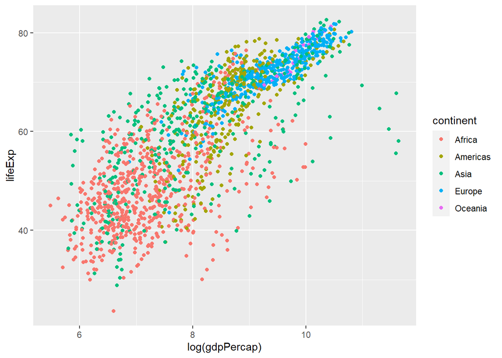

```r
library(gapminder)
ggplot(gapminder,
       aes(x = log(gdpPercap), y = lifeExp, color = continent)) +
   geom_point()
```

- Renk estetiği `geom_point()` içinde de tanımlanabilir:

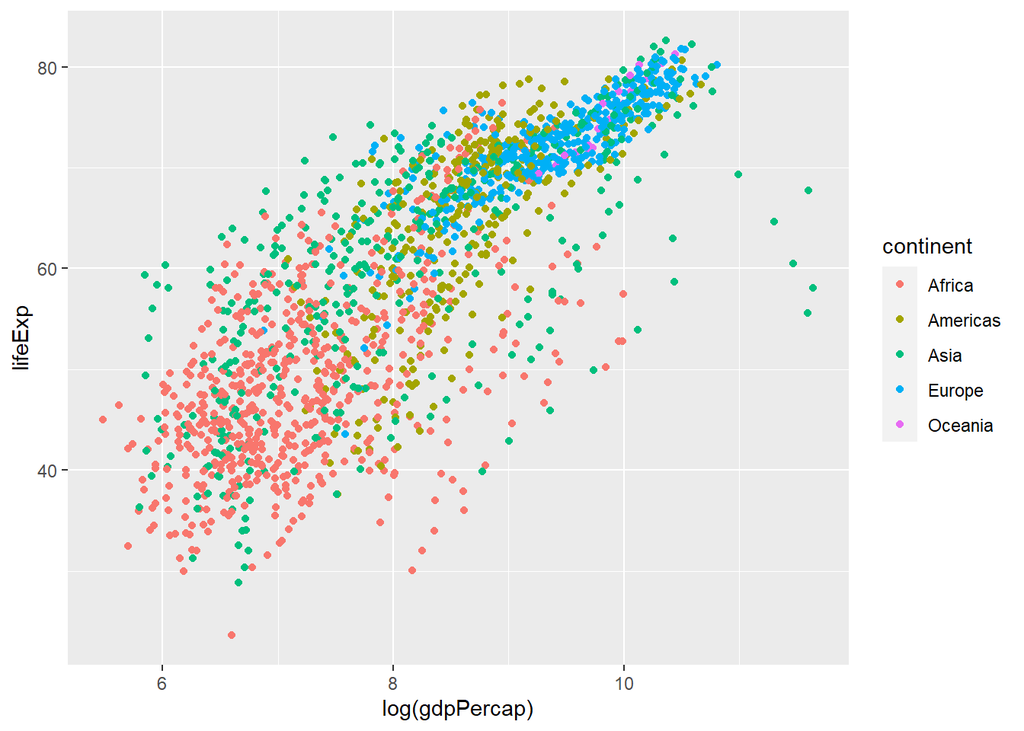

```r
ggplot(gapminder,
       aes(x = log(gdpPercap), y = lifeExp)) +
   geom_point(aes(color=continent))
```

- Kategorik bir değişkene ilişkin bilgi renkler yerine şekiller aracılığı ile de gösterilebilir. Bunun için `aes()` içinde `shape =` değişkeninin tanımlanması yeterli olur:

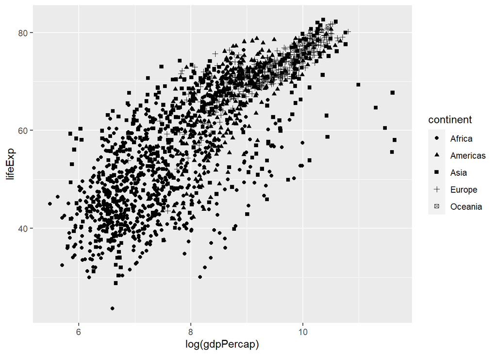

```r
ggplot(gapminder,
       aes(x = log(gdpPercap), y = lifeExp, shape = continent)) +
   geom_point()
```

- Benzer şekilde ülkelerin nüfus bilgisini `size` estetik bileşenini kullanarak tanımlayabiliriz:

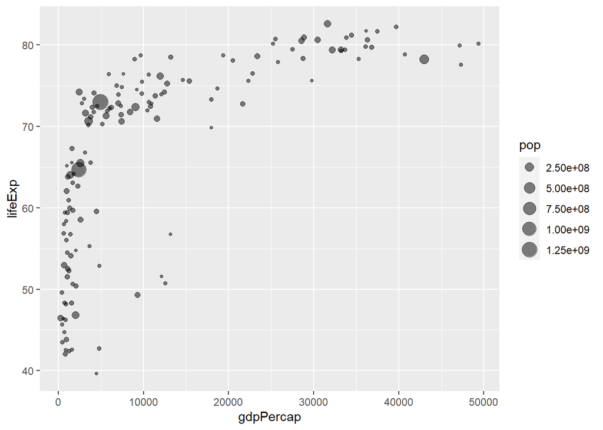

```r
# sadece 2007 yılı
gapminder |> filter(year==2007) |>
  ggplot(aes(gdpPercap, lifeExp, size = pop)) +
  geom_point(alpha = 0.5)
```

Burada `geom_point()` içinde yer alan `alpha` opsiyonu ile estetik bileşenlerin şeffaflığını kontrol edebiliriz. `alpha` parametresi 0 ile 1 arasında değerler alır, 1 durumunda mat, 0 durumunda ise şekiller görünmez olur (deneyin).

```r
# Örnek: `diamonds` data, karat ve fiyat serpilme çizimi:
ggplot(diamonds, aes(carat, price)) +
  geom_point(alpha = 0.3)
```

[output not shown]

- `color` ve `size` birlikte kullanılabilir:

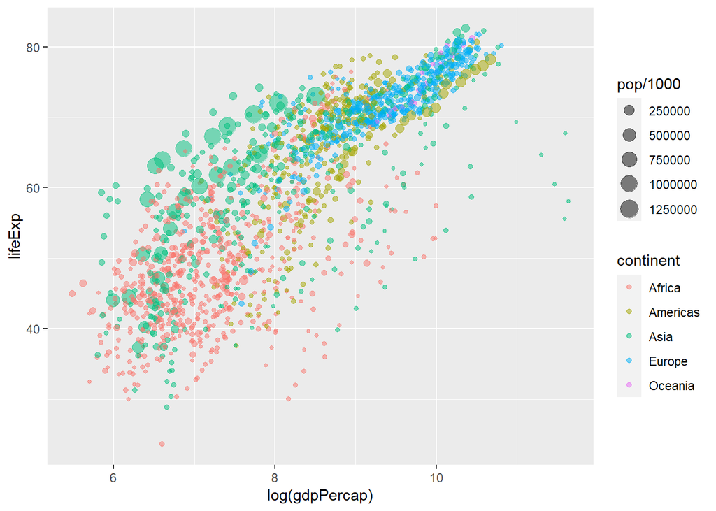

```r
# tüm yıllar
ggplot(gapminder,
       aes(x = log(gdpPercap), y = lifeExp, color = continent, size=pop/1000)) +
   geom_point(alpha = 0.5)
```

## 6.3 Fasetler

- Veri setimizde kategorik değişkenler için ayrı ayrı grafikler (facet) oluşturabiliriz.
- Örneğin `gapminder` veri setinde her kıta için ayrı ayrı serpilme çizimlerini oluşturalım.

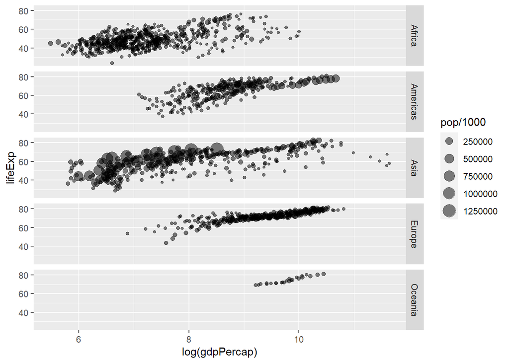

```r
ggplot(gapminder,
       aes(x = log(gdpPercap), y = lifeExp, size=pop/1000)) +
   geom_point(alpha = 0.5) +
  facet_grid(continent ~. )
```

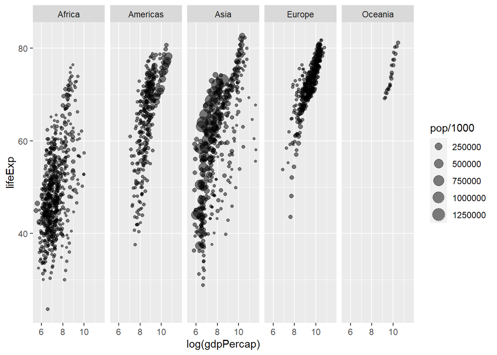

```r
ggplot(gapminder,
       aes(x = log(gdpPercap), y = lifeExp, size=pop/1000)) +
   geom_point(alpha = 0.5) +
  facet_grid(. ~ continent)
```

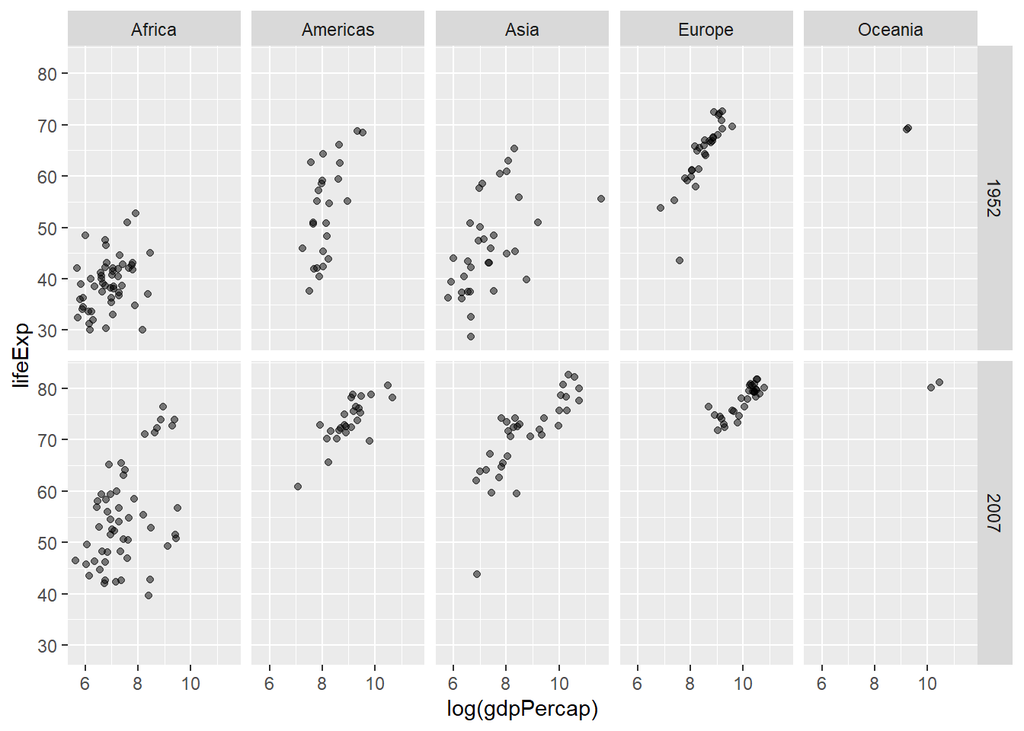

```r
gapminder |> filter(year %in% c(1952, 2007)) |>
  ggplot(aes(x = log(gdpPercap), y = lifeExp)) +
   geom_point(alpha = 0.5) +
  facet_grid(year ~ continent)
```

- Alternatif olarak `facet_wrap()` fonksiyonunu kullanabiliriz:

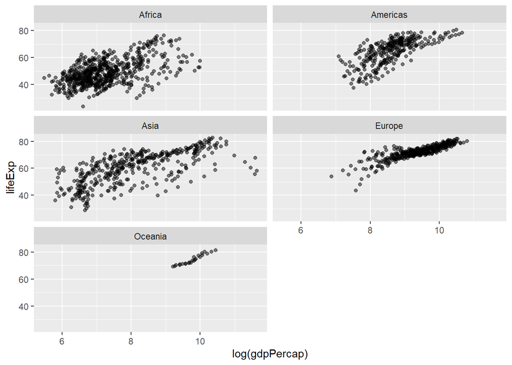

```r
ggplot(gapminder,
       aes(x = log(gdpPercap), y = lifeExp)) +
   geom_point(alpha = 0.5) +
  facet_wrap(. ~ continent, ncol = 2)
```

## 6.4 Eksenler, başlık, ve etiketlerin kontrolü

- Önce grafiğimizi oluşturalım:

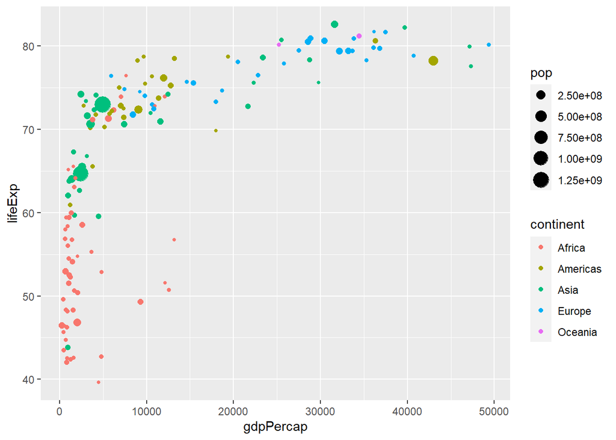

```r
# sadece 2007 yılı
g2007 <- gapminder |> filter(year==2007) |>
  ggplot(aes(gdpPercap, lifeExp, size = pop, color = continent)) +
  geom_point()
g2007
```

- Eksen başlıklarını değiştirelim:

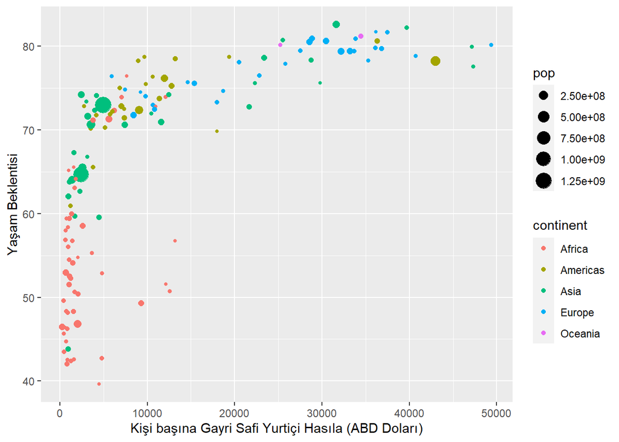

```r
g2007 +
  xlab("Kişi başına Gayri Safi Yurtiçi Hasıla (ABD Doları)") +
  ylab("Yaşam Beklentisi")
```

- Aynı işlem `labs()` fonksiyonu ile de yapılabilir.
- Başlık, alt başlık, ve dipnot ekleyelim:

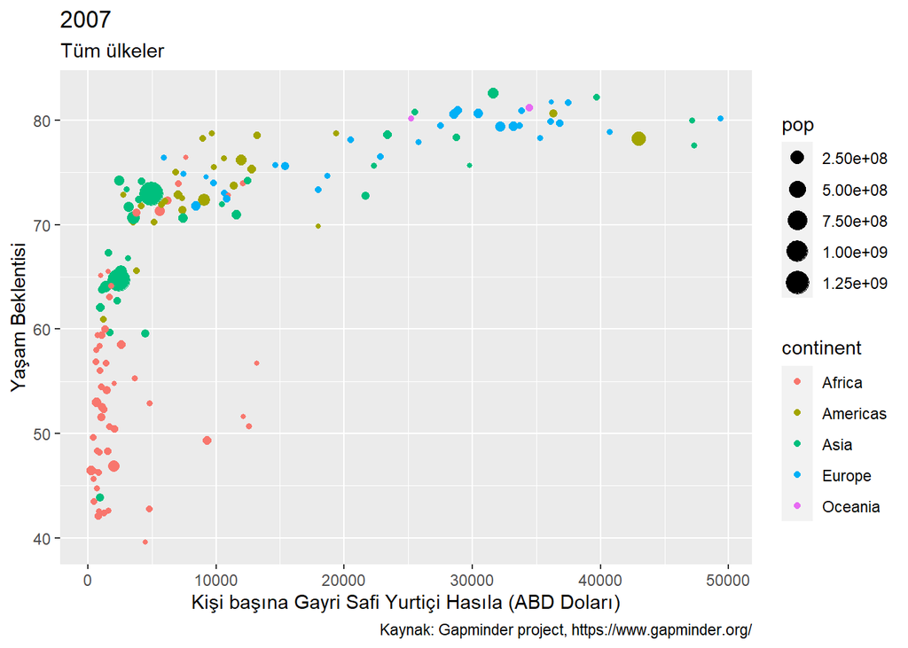

```r
g2007 +
  labs(x = "Kişi başına Gayri Safi Yurtiçi Hasıla (ABD Doları)",
       y = "Yaşam Beklentisi",
       title = "2007",
       subtitle = "Tüm ülkeler",
       caption = "Kaynak: Gapminder project, https://www.gapminder.org/"
       )
```

- `scale_x_*` veya `scale_y_*` fonksiyonlarını kullanarak eksenlerin ölçü birimlerini değiştirmek mümkündür. Örneğin yukarıdaki grafikte kişi başına GDP’yi logaritmik skala ile göstermek istersek `scale_x_log10()` fonksiyonunu kullanabiliriz:

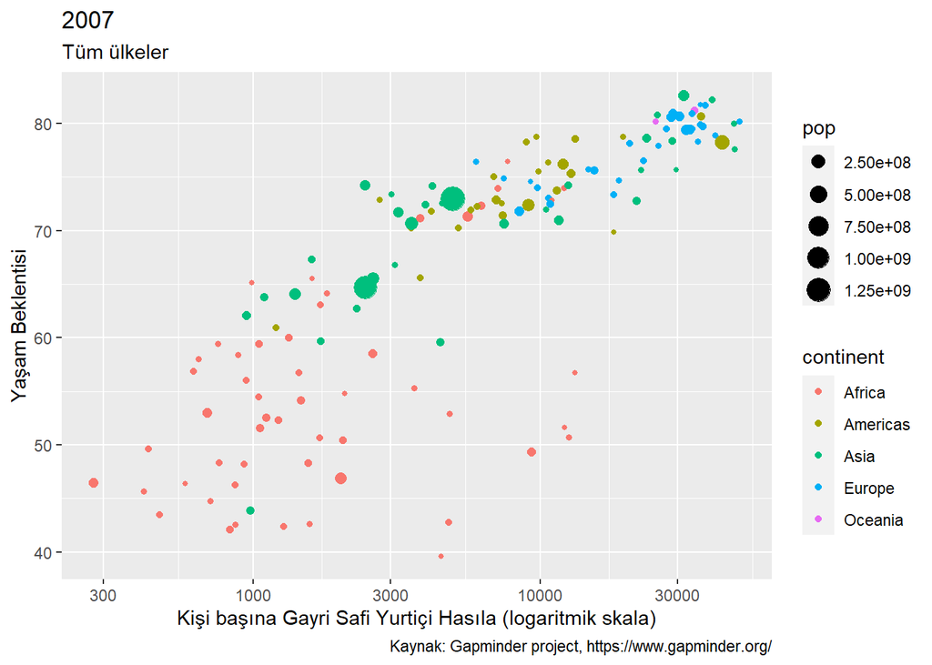

```r
g2007 +
  scale_x_log10() +
  labs(x = "Kişi başına Gayri Safi Yurtiçi Hasıla (logaritmik skala)",
       y = "Yaşam Beklentisi",
       title = "2007",
       subtitle = "Tüm ülkeler",
       caption = "Kaynak: Gapminder project, https://www.gapminder.org/"
       )
```

- Etiket başlıklarını değiştirelim:

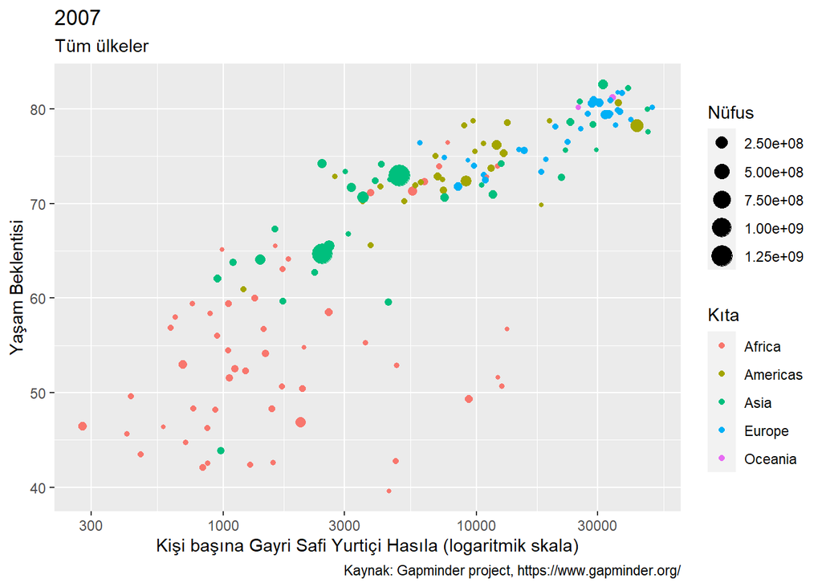

```r
g2007 +
  scale_x_log10() +
  labs(x = "Kişi başına Gayri Safi Yurtiçi Hasıla (logaritmik skala)",
       y = "Yaşam Beklentisi",
       color = "Kıta",
       size = "Nüfus",
       title = "2007",
       subtitle = "Tüm ülkeler",
       caption = "Kaynak: Gapminder project, https://www.gapminder.org/"
       )
```

- Grafiği pdf ya da png formatında saklamak için manuel olarak RStudio Plots penceresinden Export seçilebilir. Alternatif olarak `ggsave()` fonksiyonu kullanılabilir.

```r
# en son grafiği gapplot1 ismiyle sakla
ggsave("img/gapplot1.pdf")
ggsave("img/gapplot1.png")
```

## 6.5 Dağılım Grafikleri

- Sürekli bir değişkenin dağılımı betimsel istatistiğin önemli bir parçasıdır. Verilerin daha iyi anlaşılmasında histogram, kutu çizimi, birikimli dağılım fonksiyonu gibi görsel araçlar çok faydalı olabilir.

## 6.6 Histogram: `geom_histogram()`

- Örnek: Önce yapay bir veri seti oluşturalım. Veriler 3 derse ilişkin notları göstersin.

```r
set.seed(1)
n <- 200
notlar1 <- round(rnorm(n, mean = 50, sd = 10))
notlar2 <- round(rnorm(n, mean = 60, sd = 15))
notlar3 <- round(rnorm(n, mean = 70, sd = 12))
ders <-  factor( rep(c("Ekonometri-1","Ekonometri-2","Makine Öğrenmesi"), each=n) )
not_verileri <- tibble(ders,
                       not = c(notlar1, notlar2, notlar3),
                       cinsiyet = sample(c("Kadın", "Erkek"), 3*n, replace = TRUE))
not_verileri <- filter(not_verileri, not<=100 & not>=0)
head(not_verileri)
```

```
## # A tibble: 6 × 3
##   ders           not cinsiyet
##   <fct>        <dbl> <chr>
## 1 Ekonometri-1    44 Kadın
## 2 Ekonometri-1    52 Erkek
## 3 Ekonometri-1    42 Kadın
## 4 Ekonometri-1    66 Erkek
## 5 Ekonometri-1    53 Kadın
## 6 Ekonometri-1    42 Erkek
```

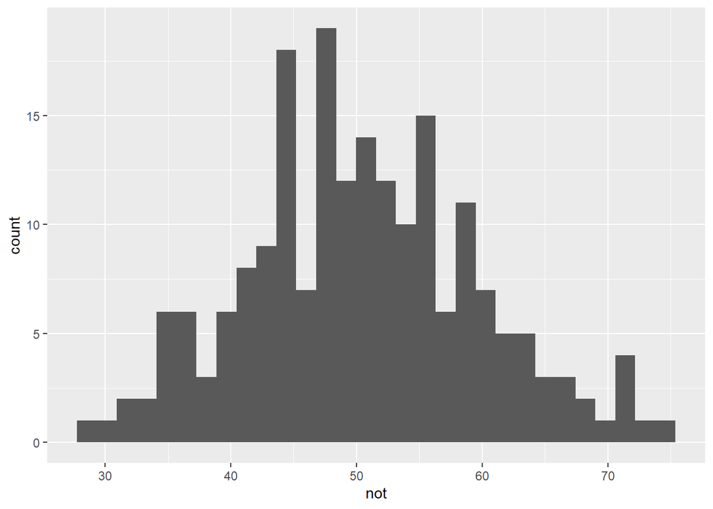

```r
not_verileri |> filter(ders == "Ekonometri-1") |>
  ggplot() +
  geom_histogram(mapping = aes(x = not))
```

- Histogramın default değerleri pek göze hitap etmiyor, sınıflar birbiriyle kaynaşmış ve sınıf sayısı da optimal değil. Yeniden çizelim:

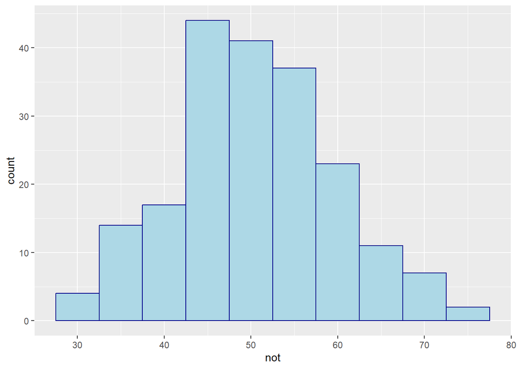

```r
not_verileri |> filter(ders == "Ekonometri-1") |>
  ggplot(mapping = aes(x = not)) +
  geom_histogram(binwidth = 5,       # sütun genişliği
                 color = "darkblue",  # sütun sınırlarının rengi
                 fill = "lightblue"   # sütun içinin rengi
                 )
```

- Diğer dersler için de histogramları çizelim ve yan yana paneller oluşturalım:

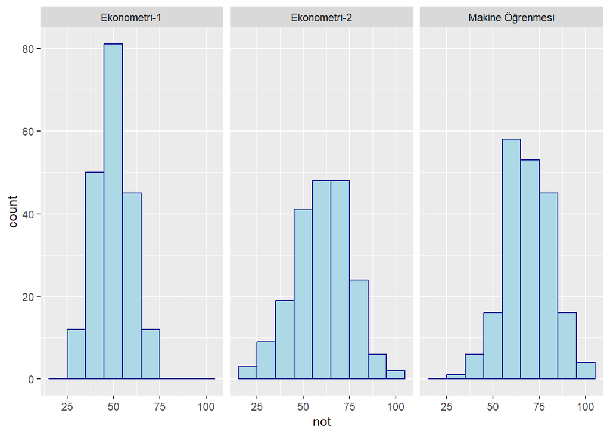

```r
ggplot(data = not_verileri) +
  geom_histogram(mapping = aes(x = not),
                 binwidth = 10,
                 color = "darkblue",
                 fill  = "lightblue"
                 ) +
  facet_wrap(~ ders)
```

- Grupların histogramlarını aynı grafikte göster:

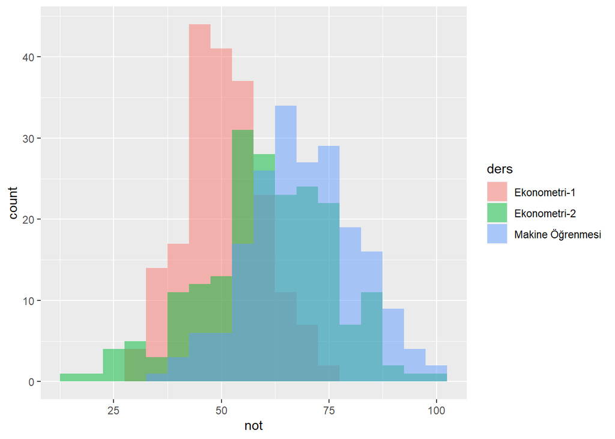

```r
not_verileri |> ggplot(aes(x = not, fill = ders)) +
  geom_histogram(binwidth=5, alpha=.5, position="identity")
```

- Histogram üzerinde ortalama veya medyan notu bir çizgi ya da nokta ile gösterebiliriz.

```r
not_ort <- not_verileri |> group_by(ders) |>
  summarize(n = n(),
            ortalama = mean(not),
            medyan = median(not),
            sd = sd(not),
            se_ort = ortalama/sqrt(n),
            p25 = quantile(not, 0.25),
            p75 = quantile(not, 0.75)
            )
not_ort
```

```
## # A tibble: 3 × 8
##   ders                 n ortalama medyan    sd se_ort   p25   p75
##   <fct>            <int>    <dbl>  <dbl> <dbl>  <dbl> <dbl> <dbl>
## 1 Ekonometri-1       200     50.4   49.5  9.30   3.56  44    56
## 2 Ekonometri-2       200     60.6   60   15.2    4.28  52.8  71
## 3 Makine Öğrenmesi   199     69.3   69   12.4    4.91  61    77.5
```

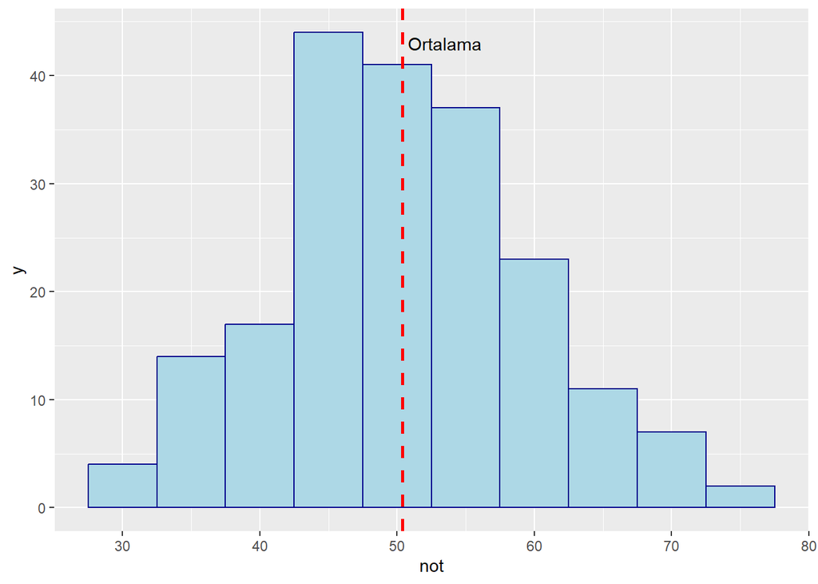

```r
not_verileri |> filter(ders == "Ekonometri-1") |>
  ggplot(mapping = aes(x = not)) +
  geom_histogram(binwidth = 5,       # sütun genişliği
                 color = "darkblue", # sütun sınırlarının rengi
                 fill = "lightblue"  # sütun içinin rengi
                 )  +
  geom_vline(aes(xintercept = mean(not)), # dikey çizginin yeri=ortalama
             linetype = "dashed",         # çizgi tipi
             color = "red",               # çizgi rengi
             size = 1                     # çizgi büyüklüğü
             ) +
  annotate(geom = "text",      # geom türü
           label = "Ortalama", # yazmak istediğimiz etiket/bilgi/yazı
           x = 53.5,           # x koordinatı
           y = 43)             # y koordinatı
```